# Seedling density across a gradient of fire severity

Anna Talucci

20 July 2019

# Overview

For short interval beetle+fire disturbances we are interested if time since beetle attack impacts the aerial seedbank and subsequent regeneration after fire. Seedling count data was acquired over various sized plots; in order to account for this we analyzed out data as a negative bionomial and accounted for the effort of the seedling count collection. Effort refers to the log of the area in which seedlings were counted in.

The goal of this analysis is twofold. First, to assess seedling density as a function of plots burning or not burning. Second, to assess seedling density as a function of the type of burning conditions - unburned, surface, severe surface, and crown.

Seedling density was gathered as a variety of scales from 1 square meter to 100 square meters. Seedlings is being used broadly to include saplings (larger, older, more developed trees) in unburned plots. Due to the variability in plot size for data collection, we will account for this in our statistical models. Plot size is the effort and is accounted for in the statistical model with an offset for area.

# Packages

The following Packages are required for the below analyses:

# Data

Burn plot data

```r
fire = read.csv("../data/2018-09-20_ch2-burnedplots-wcodes-edit43.csv", header = TRUE, sep = ",", strip.white = TRUE)
head(fire)
```

```
##   plot   Plot_ID plot.mpb stems bom fire live upf no.canopy yes.canopy
## 1    1 CEC0629M1      LM1     7   0    7    0   0         0          7
## 2    2 CEC0630H1      LM2     7   0    7    0   0         0          7
## 3    3 CEC0701L1      LL3    42  17   21    3   1         4         38
## 4    4 CEC0702M1      HM4    12  12    0    0   0         0         12
## 5    5 CEC0702H1      LH5    24   0    9    0  15        15          9
## 6    6 CEC0703M1      LL6    20  16    4    0   0        10         10
##   no.seed yes.seed tot.stem cone.ct seed.density disturbance fire.type
## 1       0        7        7     282           75 beetle+fire  sev.surf
## 2       0        7        7    1150         1700 beetle+fire  sev.surf
## 3      28       14       42    3665          375 beetle+fire   surface
## 4       6        6       12    1286          150 beetle+fire  sev.surf
## 5      15        9       24    1585          375 beetle+fire     crown
## 6      15        5       20     680            2 beetle+fire   surface
##    burncon
## 1 moderate
## 2 moderate
## 3 moderate
## 4 moderate
## 5 moderate
## 6 moderate
```

Burn plot data: Seedling Effort (area collected)

```r
fire.seedeffort = read.csv("../data/chapter2_analysis34_seedlingeffort_11december2017.csv", header = TRUE, sep = ",", strip.white = TRUE)
head(fire.seedeffort)
```

```
##   plot seedling.ct seedling.area
## 1    1           3             4
## 2    2          68             4
## 3    3          15             4
## 4    4           6             4
## 5    5          15             4
## 6    6           0             4
```

Here we will combine our effort data with our burn plot data

```r
burned3 = merge(fire, fire.seedeffort, by = c("plot"))
head(burned3)
```

```
##   plot   Plot_ID plot.mpb stems bom fire live upf no.canopy yes.canopy
## 1    1 CEC0629M1      LM1     7   0    7    0   0         0          7
## 2    2 CEC0630H1      LM2     7   0    7    0   0         0          7
## 3    3 CEC0701L1      LL3    42  17   21    3   1         4         38
## 4    4 CEC0702M1      HM4    12  12    0    0   0         0         12
## 5    5 CEC0702H1      LH5    24   0    9    0  15        15          9
## 6    6 CEC0703M1      LL6    20  16    4    0   0        10         10
##   no.seed yes.seed tot.stem cone.ct seed.density disturbance fire.type
## 1       0        7        7     282           75 beetle+fire  sev.surf
## 2       0        7        7    1150         1700 beetle+fire  sev.surf
## 3      28       14       42    3665          375 beetle+fire   surface
## 4       6        6       12    1286          150 beetle+fire  sev.surf
## 5      15        9       24    1585          375 beetle+fire     crown
## 6      15        5       20     680            2 beetle+fire   surface
##    burncon seedling.ct seedling.area
## 1 moderate           3             4
## 2 moderate          68             4
## 3 moderate          15             4
## 4 moderate           6             4
## 5 moderate          15             4
## 6 moderate           0             4
```

```r
burned3 = mutate(burned3, prop.bom = bom/stems)
head(burned3)
```

```
##   plot   Plot_ID plot.mpb stems bom fire live upf no.canopy yes.canopy
## 1    1 CEC0629M1      LM1     7   0    7    0   0         0          7
## 2    2 CEC0630H1      LM2     7   0    7    0   0         0          7
## 3    3 CEC0701L1      LL3    42  17   21    3   1         4         38
## 4    4 CEC0702M1      HM4    12  12    0    0   0         0         12
## 5    5 CEC0702H1      LH5    24   0    9    0  15        15          9
## 6    6 CEC0703M1      LL6    20  16    4    0   0        10         10
##   no.seed yes.seed tot.stem cone.ct seed.density disturbance fire.type
## 1       0        7        7     282           75 beetle+fire  sev.surf
## 2       0        7        7    1150         1700 beetle+fire  sev.surf
## 3      28       14       42    3665          375 beetle+fire   surface
## 4       6        6       12    1286          150 beetle+fire  sev.surf
## 5      15        9       24    1585          375 beetle+fire     crown
## 6      15        5       20     680            2 beetle+fire   surface
##    burncon seedling.ct seedling.area  prop.bom
## 1 moderate           3             4 0.0000000
## 2 moderate          68             4 0.0000000
## 3 moderate          15             4 0.4047619
## 4 moderate           6             4 1.0000000
## 5 moderate          15             4 0.0000000
## 6 moderate           0             4 0.8000000
```

Select plot, fire.type, seedling.ct, seedling area

```r
( burnt.plot = burned3 %>%
    dplyr::select(plot, fire.type, seedling.ct:prop.bom) )
```

```
##    plot fire.type seedling.ct seedling.area   prop.bom
## 1     1  sev.surf           3             4 0.00000000
## 2     2  sev.surf          68             4 0.00000000
## 3     3   surface          15             4 0.40476190
## 4     4  sev.surf           6             4 1.00000000
## 5     5     crown          15             4 0.00000000
## 6     6   surface           0             4 0.80000000
## 7     7     crown           4             4 1.00000000
## 8     8     crown           6             4 1.00000000
## 9     9     crown           6             4 1.00000000
## 10   10     crown           5             4 0.00000000
## 11   11     crown           3             4 1.00000000
## 12   12   surface          13             4 0.50000000
## 13   13   surface           8             4 0.66666667
## 14   14   surface           0             4 0.70000000
```

[output cut: 49 more lines]

Unburned Data

```r
unburnt3 = read.csv("../data/chapter2_unburnplotsapcondensed_11november2017.csv", header=TRUE, sep = ",", strip.white = TRUE)

head(unburnt3)
```

```
##   plot plot.mpb stems bom LIVE UPF Var.7 no.canopy yes.canopy no.seed
## 1   64     HU64     2   2    0   0     0         0          2       1
## 2   65     HU65    12  11    0   1     0         3          9       6
## 3   66     LU66    30  15   14   1     0         2         28      25
## 4   67     MU67     5   5    0   0     0         0          5       3
## 5   68     MU68    26  18    4   4     0         3         23      24
## 6   69     MU69     5   5    0   0     0         1          4       3
##   yes.seed     fire  n cone.ct disturbance sapling.density
## 1        1 unburned  2     500 beetle.only              10
## 2        6 unburned 12     475 beetle.only               7
## 3        5 unburned 30    2100 beetle.only              40
## 4        2 unburned  5     970 beetle.only              14
## 5        2 unburned 26    1618 beetle.only              37
## 6        2 unburned  5     424 beetle.only              22
```

```r
unburnt3 = mutate(unburnt3, prop.bom = bom/stems)
head(unburnt3)
```

```
##   plot plot.mpb stems bom LIVE UPF Var.7 no.canopy yes.canopy no.seed
## 1   64     HU64     2   2    0   0     0         0          2       1
## 2   65     HU65    12  11    0   1     0         3          9       6
## 3   66     LU66    30  15   14   1     0         2         28      25
## 4   67     MU67     5   5    0   0     0         0          5       3
## 5   68     MU68    26  18    4   4     0         3         23      24
## 6   69     MU69     5   5    0   0     0         1          4       3
##   yes.seed     fire  n cone.ct disturbance sapling.density  prop.bom
## 1        1 unburned  2     500 beetle.only              10 1.0000000
## 2        6 unburned 12     475 beetle.only               7 0.9166667
## 3        5 unburned 30    2100 beetle.only              40 0.5000000
## 4        2 unburned  5     970 beetle.only              14 1.0000000
## 5        2 unburned 26    1618 beetle.only              37 0.6923077
## 6        2 unburned  5     424 beetle.only              22 1.0000000
```

```r
unburnt.plot = unburnt3 %>%
    dplyr::select(plot, fire, sapling.density, prop.bom)

head(unburnt.plot)
```

```
##   plot     fire sapling.density  prop.bom
## 1   64 unburned              10 1.0000000
## 2   65 unburned               7 0.9166667
## 3   66 unburned              40 0.5000000
## 4   67 unburned              14 1.0000000
## 5   68 unburned              37 0.6923077
## 6   69 unburned              22 1.0000000
```

```r
unburnt.plot = mutate(unburnt.plot, fire.type = fire)
unburnt.plot = mutate(unburnt.plot, seedling.ct = sapling.density)
unburnt.plot = mutate(unburnt.plot, seedling.area = 100)

head(unburnt.plot)
```

```
##   plot     fire sapling.density  prop.bom fire.type seedling.ct
## 1   64 unburned              10 1.0000000  unburned          10
## 2   65 unburned               7 0.9166667  unburned           7
## 3   66 unburned              40 0.5000000  unburned          40
## 4   67 unburned              14 1.0000000  unburned          14
## 5   68 unburned              37 0.6923077  unburned          37
## 6   69 unburned              22 1.0000000  unburned          22
##   seedling.area
## 1           100
## 2           100
## 3           100
## 4           100
## 5           100
## 6           100
```

```r
unburnt.plot2 = unburnt.plot %>%
    dplyr::select(plot, fire.type, seedling.ct, seedling.area, prop.bom)
```

```r
seedlings.plot = rbind(burnt.plot, unburnt.plot2)

head(seedlings.plot)
```

```
##   plot fire.type seedling.ct seedling.area  prop.bom
## 1    1  sev.surf           3             4 0.0000000
## 2    2  sev.surf          68             4 0.0000000
## 3    3   surface          15             4 0.4047619
## 4    4  sev.surf           6             4 1.0000000
## 5    5     crown          15             4 0.0000000
## 6    6   surface           0             4 0.8000000
```

```r
write.csv(seedlings.plot, file = "../output/2018-08-20_allseedlings.csv")
```

```r
seedlings.plot = mutate(seedlings.plot, seedling.per.area = seedling.ct/seedling.area)

head(seedlings.plot)
```

```
##   plot fire.type seedling.ct seedling.area  prop.bom seedling.per.area
## 1    1  sev.surf           3             4 0.0000000              0.75
## 2    2  sev.surf          68             4 0.0000000             17.00
## 3    3   surface          15             4 0.4047619              3.75
## 4    4  sev.surf           6             4 1.0000000              1.50
## 5    5     crown          15             4 0.0000000              3.75
## 6    6   surface           0             4 0.8000000              0.00
```

[output not shown]

[figure not shown]

```r
seedlings.plot$fire.type = factor(seedlings.plot$fire.type,
       levels = c("crown", "sev.surf", "surface", "unburned"),
       labels = c("Crown", "Severe Surface", "Light Surface", "Fire refugia"))

head(seedlings.plot)
```

### MODEL

```r
fitcomp1 = glm.nb(seedling.ct ~ fire.type + offset(log(seedling.area)), data = seedlings.plot)
```

#### Residuals

In the plot below we are looking for the points in the QQ plot to fall along the RED linen. In the Residuals vs.predicted plot were are looking for the lines to be relatively horizontal. All looks good.

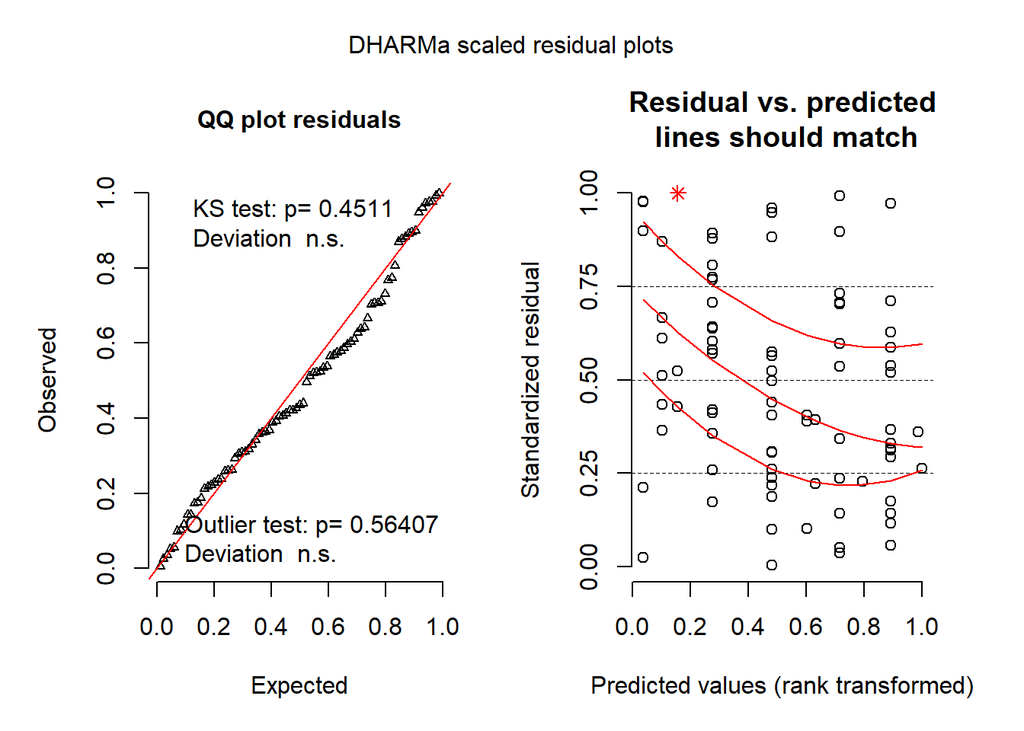

QQ plot looks ok with no significant deviations from the plot line. The residual vs predicted plot looks ok, lines are relatively horizontal. Th lack of horizontality maybe due to lack of data in certain regions, but these generally look adequate.

QQplot looks ok with no significant deviations. The residual vs predicted plot looks ok with lines that are relatively horizontal.

Evaluate overdispersion in the model.

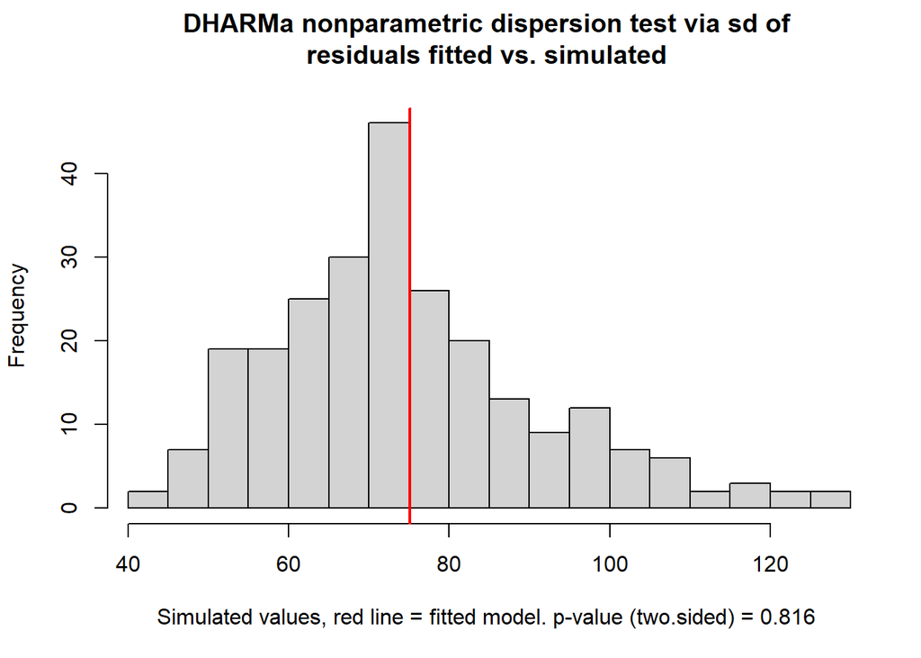

```
##
##  DHARMa nonparametric dispersion test via sd of residuals fitted
##  vs. simulated
##
## data:  simulationOutput
## ratioObsSim = 1.006, p-value = 0.816
## alternative hypothesis: two.sided
```

```r
testDispersion(fitcomp1.res)
```

#### Summary

```r
summary(fitcomp1)
```

```
##
## Call:
## glm.nb(formula = seedling.ct ~ fire.type + offset(log(seedling.area)),
##     data = seedlings.plot, init.theta = 0.8452446581, link = log)
##
## Deviance Residuals:
##      Min        1Q    Median        3Q       Max
## -2.57759  -1.01667  -0.50047   0.06124   3.02381
##
## Coefficients:
##                         Estimate Std. Error z value Pr(>|z|)
## (Intercept)              0.54534    0.24195   2.254   0.0242 *
## fire.typeSevere Surface  0.09415    0.34501   0.273   0.7849
## fire.typeLight Surface  -0.75433    0.32965  -2.288   0.0221 *
## fire.typeFire refugia   -1.83099    0.36092  -5.073 3.91e-07 ***
## ---
## Signif. codes:  0 '***' 0.001 '**' 0.01 '*' 0.05 '.' 0.1 ' ' 1
##
## (Dispersion parameter for Negative Binomial(0.8452) family taken to be 1)
##
##     Null deviance: 126.165  on 82  degrees of freedom
## Residual deviance:  97.343  on 79  degrees of freedom
## AIC: 787.06
##
## Number of Fisher Scoring iterations: 1
##
##
##               Theta:  0.845
##           Std. Err.:  0.123
##
##  2 x log-likelihood:  -777.058
```

#### Estimates

```r
lsmeans(fitcomp1, pairwise ~ fire.type, type = "response", infer = TRUE, level = .95, adjust = 'bon')
```

```
## $lsmeans
##  fire.type      response    SE  df asymp.LCL asymp.UCL
##  Crown              97.6 23.62 Inf     60.76     156.9
##  Severe Surface    107.3 26.38 Inf     66.24     173.7
##  Light Surface      45.9 10.28 Inf     29.61      71.2
##  Fire refugia       15.6  4.19 Inf      9.26      26.4
##
## Confidence level used: 0.95
## Intervals are back-transformed from the log scale
##
## $contrasts
##  contrast                       ratio    SE  df z.ratio p.value
##  Crown / Severe Surface          0.91 0.314 Inf -0.273  1.0000
##  Crown / Light Surface           2.13 0.701 Inf  2.288  0.1327
##  Crown / Fire refugia            6.24 2.252 Inf  5.073  <.0001
##  Severe Surface / Light Surface  2.34 0.777 Inf  2.551  0.0644
##  Severe Surface / Fire refugia   6.86 2.493 Inf  5.295  <.0001
##  Light Surface / Fire refugia    2.93 1.024 Inf  3.084  0.0122
##
## P value adjustment: bonferroni method for 6 tests
## Tests are performed on the log scale
```

```r
summary(lsmeans(fitcomp1, pairwise ~ fire.type), type = "response", infer = TRUE, level = .95, adjust = "bon")
```

```
## $lsmeans
##  fire.type      response    SE  df asymp.LCL asymp.UCL z.ratio p.value
##  Crown              97.6 23.62 Inf     53.35     178.7 18.934  <.0001
##  Severe Surface    107.3 26.38 Inf     58.03     198.3 19.009  <.0001
##  Light Surface      45.9 10.28 Inf     26.25      80.3 17.093  <.0001
##  Fire refugia       15.6  4.19 Inf      8.01      30.5 10.269  <.0001
##
## Confidence level used: 0.95
## Conf-level adjustment: bonferroni method for 4 estimates
## Intervals are back-transformed from the log scale
## P value adjustment: bonferroni method for 4 tests
## Tests are performed on the log scale
##
## $contrasts
##  contrast                       ratio    SE  df asymp.LCL asymp.UCL
##  Crown / Severe Surface          0.91 0.314 Inf     0.366      2.26
##  Crown / Light Surface           2.13 0.701 Inf     0.891      5.07
##  Crown / Fire refugia            6.24 2.252 Inf     2.408     16.17
##  Severe Surface / Light Surface  2.34 0.777 Inf     0.971      5.62
##  Severe Surface / Fire refugia   6.86 2.493 Inf     2.627     17.89
##  Light Surface / Fire refugia    2.93 1.024 Inf     1.169      7.37
##  z.ratio p.value
##  -0.273  1.0000
##   2.288  0.1327
##   5.073  <.0001
##   2.551  0.0644
##   5.295  <.0001
##   3.084  0.0122
##
## Confidence level used: 0.95
## Conf-level adjustment: bonferroni method for 6 estimates
## Intervals are back-transformed from the log scale
## P value adjustment: bonferroni method for 6 tests
## Tests are performed on the log scale
```

#### Data Frame

Place model summary information into a dataframe.

```r
(summary(lsmeans(fitcomp1, pairwise ~ fire.type, type = "response", infer = TRUE)))
```

```
## $lsmeans
##  fire.type      response    SE  df asymp.LCL asymp.UCL
##  Crown              97.6 23.62 Inf     60.76     156.9
##  Severe Surface    107.3 26.38 Inf     66.24     173.7
##  Light Surface      45.9 10.28 Inf     29.61      71.2
##  Fire refugia       15.6  4.19 Inf      9.26      26.4
##
## Confidence level used: 0.95
## Intervals are back-transformed from the log scale
##
## $contrasts
##  contrast                       ratio    SE  df z.ratio p.value
##  Crown / Severe Surface          0.91 0.314 Inf -0.273  0.9929
##  Crown / Light Surface           2.13 0.701 Inf  2.288  0.1007
##  Crown / Fire refugia            6.24 2.252 Inf  5.073  <.0001
##  Severe Surface / Light Surface  2.34 0.777 Inf  2.551  0.0524
##  Severe Surface / Fire refugia   6.86 2.493 Inf  5.295  <.0001
##  Light Surface / Fire refugia    2.93 1.024 Inf  3.084  0.0110
##
## P value adjustment: tukey method for comparing a family of 4 estimates
## Tests are performed on the log scale
```

```r
( fitcomp1.graph = data.frame(summary(lsmeans(fitcomp1, pairwise ~ fire.type, type = "response", infer = TRUE))$lsmeans) )
```

```
##        fire.type  response       SE  df asymp.LCL asymp.UCL
## 1          Crown  97.62909 23.62173 Inf 60.761402 156.86667
## 2 Severe Surface 107.26732 26.38207 Inf 66.239491 173.70722
## 3  Light Surface  45.91733 10.28040 Inf 29.607493  71.21173
## 4   Fire refugia  15.64557  4.19001 Inf  9.256201  26.44539
```

```r
( data.frame(summary(lsmeans(fitcomp1, pairwise ~ fire.type, type = "response", infer = TRUE))$contrasts) )
```

```
##                         contrast     ratio        SE  df    z.ratio
## 1         Crown / Severe Surface 0.9101476 0.3140096 Inf -0.2728868
## 2          Crown / Light Surface 2.1261928 0.7008961 Inf  2.2882954
## 3           Crown / Fire refugia 6.2400466 2.2521537 Inf  5.0731209
## 4 Severe Surface / Light Surface 2.3360968 0.7769633 Inf  2.5511308
## 5  Severe Surface / Fire refugia 6.8560822 2.4929290 Inf  5.2945318
## 6   Light Surface / Fire refugia 2.9348451 1.0244568 Inf  3.0843806
##        p.value
## 1 9.929016e-01
## 2 1.007136e-01
## 3 2.336383e-06
## 4 5.242390e-02
## 5 7.135808e-07
## 6 1.098036e-02
```

#### Figure

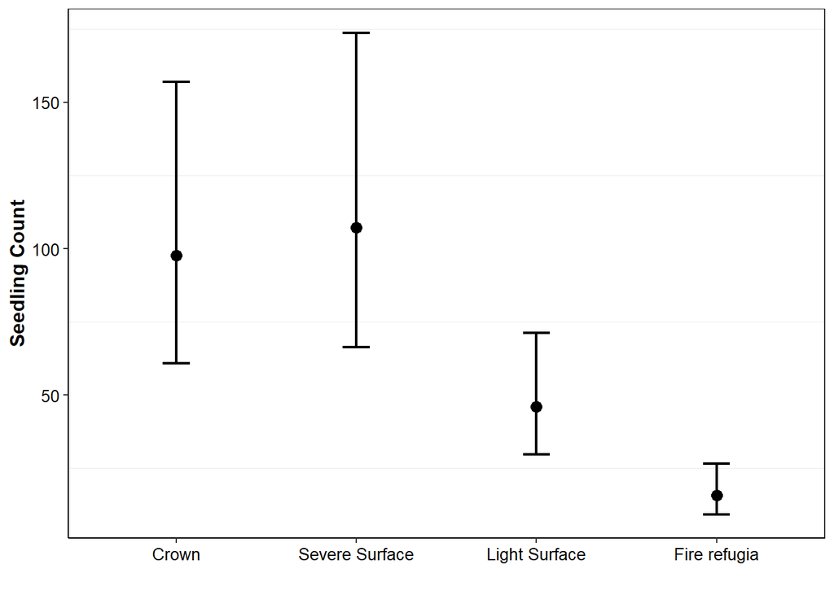

## Extract Etimates for Graph

```r
( response.plot = data.frame(summary(lsmeans(fitcomp1, pairwise ~ fire.type), type = "response", infer = TRUE)$lsmeans))
```

```
##        fire.type  response       SE  df asymp.LCL asymp.UCL  z.ratio
## 1          Crown  97.62909 23.62173 Inf 60.761402 156.86667 18.93409
## 2 Severe Surface 107.26732 26.38207 Inf 66.239491 173.70722 19.00948
## 3  Light Surface  45.91733 10.28040 Inf 29.607493  71.21173 17.09256
## 4   Fire refugia  15.64557  4.19001 Inf  9.256201  26.44539 10.26925
##        p.value
## 1 5.973708e-80
## 2 1.423550e-80
## 3 1.686001e-65
## 4 9.695555e-25
```

## Manuscript Figure

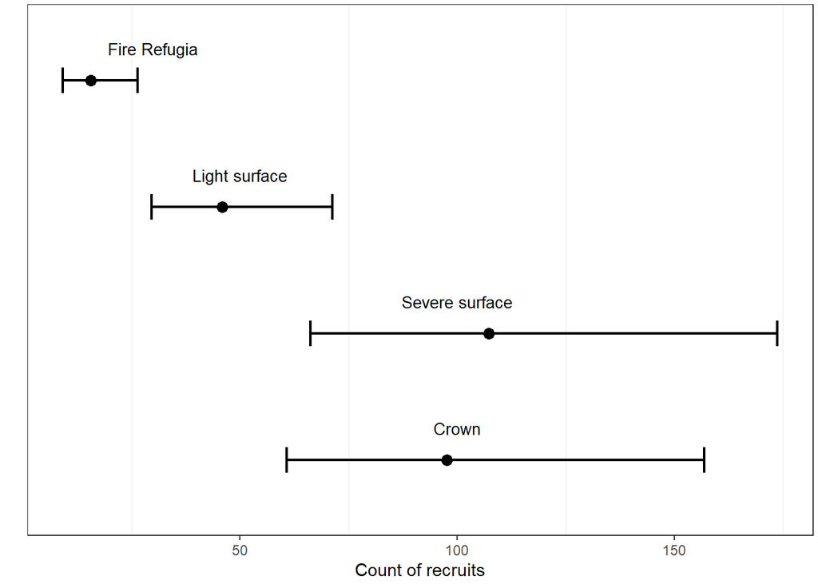

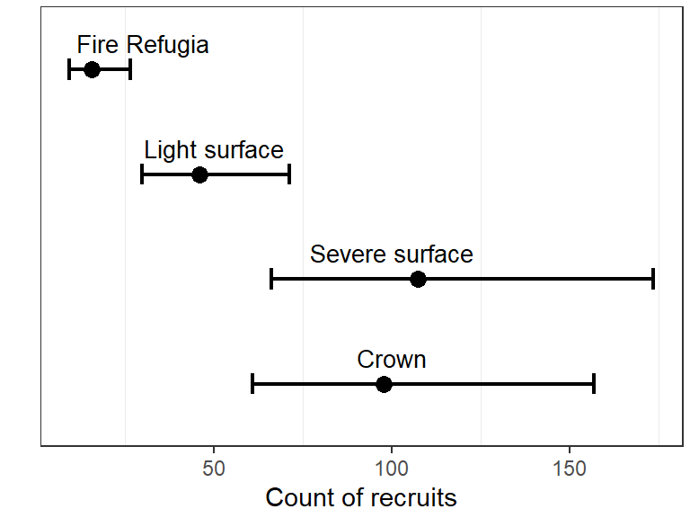

## Extract Odds Ratios for graph

```r
( rec.contrast = data.frame(summary(lsmeans(fitcomp1, pairwise ~ fire.type),type = "response", infer = TRUE)$contrasts))
```

```
##                         contrast     ratio        SE  df asymp.LCL
## 1         Crown / Severe Surface 0.9101476 0.3140096 Inf 0.3751277
## 2          Crown / Light Surface 2.1261928 0.7008961 Inf 0.9116088
## 3           Crown / Fire refugia 6.2400466 2.2521537 Inf 2.4689039
## 4 Severe Surface / Light Surface 2.3360968 0.7769633 Inf 0.9940640
## 5  Severe Surface / Fire refugia 6.8560822 2.4929290 Inf 2.6939666
## 6   Light Surface / Fire refugia 2.9348451 1.0244568 Inf 1.1970870
##   asymp.UCL    z.ratio      p.value
## 1  2.208231 -0.2728868 9.929016e-01
## 2  4.959030  2.2882954 1.007136e-01
## 3 15.771445  5.0731209 2.336383e-06
## 4  5.489937  2.5511308 5.242390e-02
## 5 17.448570  5.2945318 7.135808e-07
## 6  7.195230  3.0843806 1.098036e-02
```

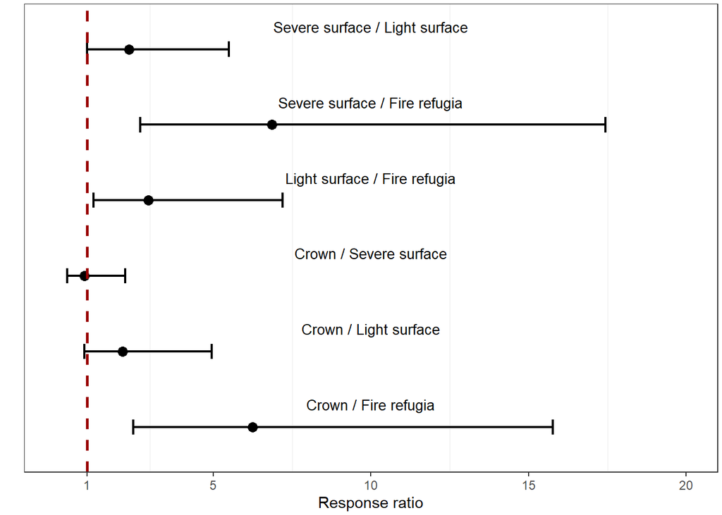

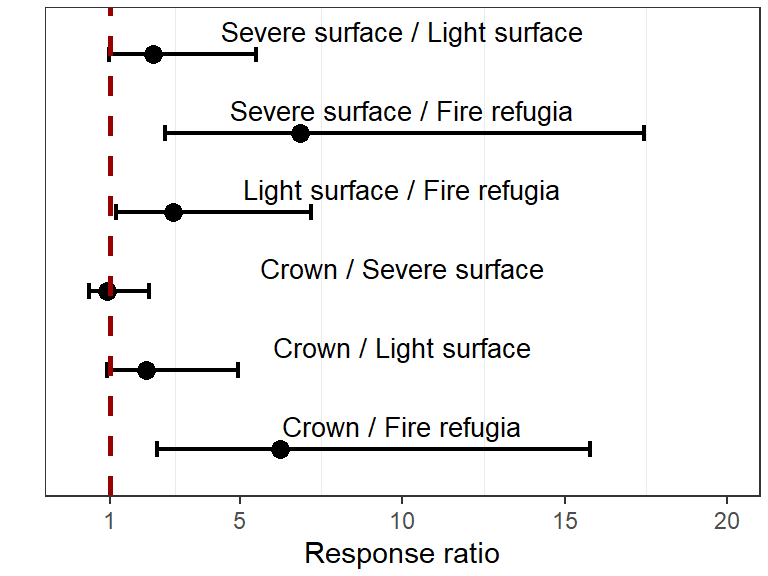

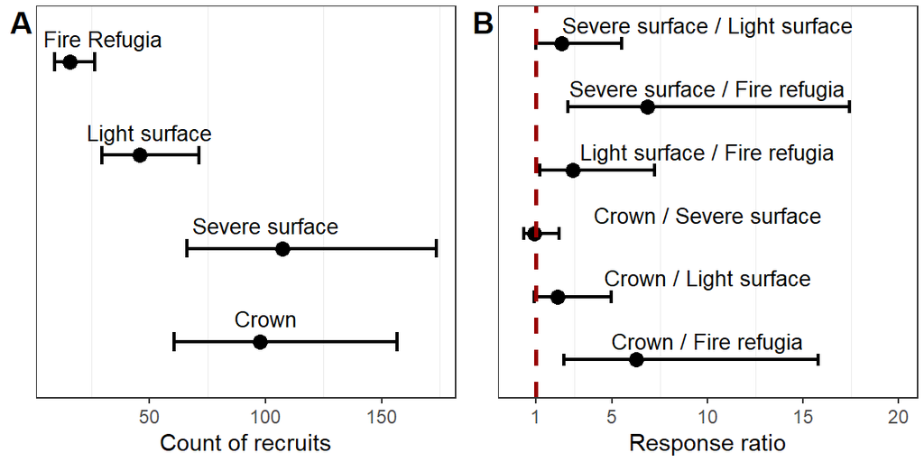